# mdmb_ch1

# Chapter 1 - Generative Models for Discrete Data

## Section 1.1 Objectives

Actions of counting permeate biology and often consider the following questions:  
- How **much**?  
- How **often**?  
- How **many**?

The results of interrigating these questions result in *discrete* variables, they are quantized, not continuous.

This chapter considers a **top down** approach to understanding the outcome of events, or *probabilities*. These probabilities differ based on the model on which these outcomes occur.

## Section 1.2 HIV mutation rate

Given a mutation rate of 5x10^-4 nt per replication cycle, then the rate of mutations along the HIV genome of about 10,000 nt will follow a Poisson distribution with a rate of 5. The standard error will be 5^1/2

The *Poisson* distribution can be thought of as the rate of occurances happening along a streamline. For example, Poisson distributions can be used to model the probability of hitting potholes as you drive along a street of a given length.

The Poisson distribution can also allow us to understand the probability of seeing other events, for example 3 or even 100.

This can be done by taking the value of the *rate parameter*, noted by lambda.

```r
dpois(x=3, lambda=5)
```

```
## [1] 0.1403739
```

```r
dpois(x=100, lambda=5)
```

```
## [1] 5.695402e-91
```

As you an see, 3 mutations occuring in a replication cycle has a 14% probability given the Poisson distribution, but 100 (20x more than lambda) has almost a one in megasuperduperkabillion chance of ever happening.

The distribution of probabilities between 0 and 12 mutations gives us a better idea of the probability distribution of this event.

```r
hivpois <- dpois(x=0:12, lambda=5)
hivpois
```

```
##  [1] 0.006737947 0.033689735 0.084224337 0.140373896 0.175467370
##  [6] 0.175467370 0.146222808 0.104444863 0.065278039 0.036265577
## [11] 0.018132789 0.008242177 0.003434240
```

And visualizing that:

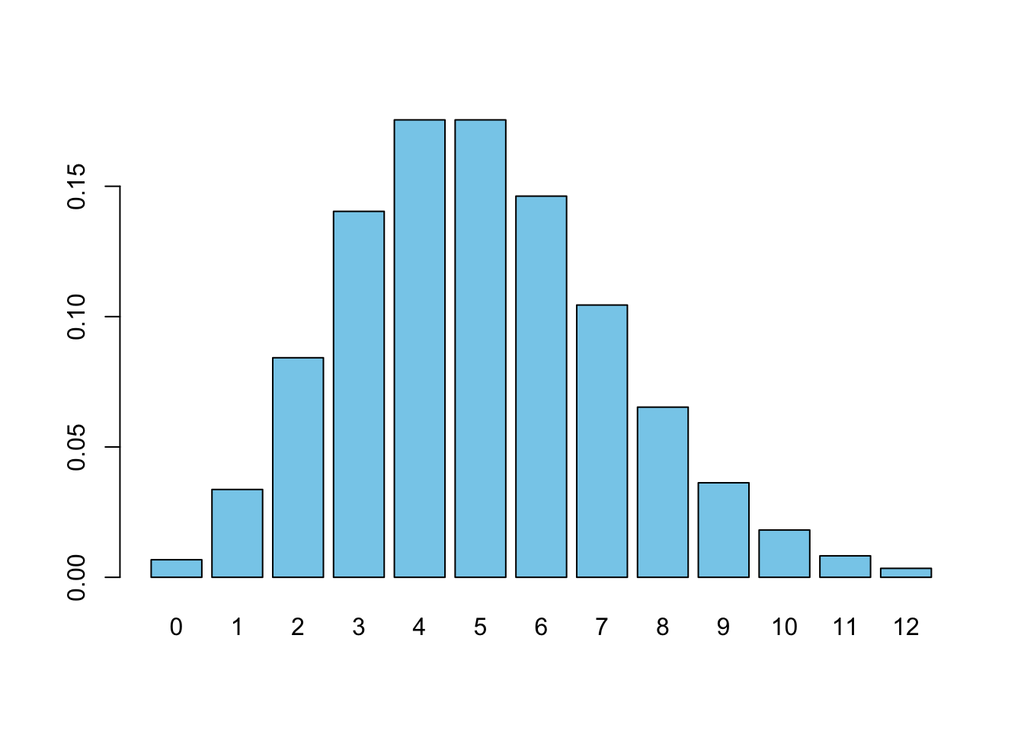

```r
barplot(hivpois, names.arg = 0:12, col = "skyblue")
```

The Poisson probability of seeing x can be defined by the formula:

(e^-lambda x lambda^x) / x!

but dpois() is easier to write.

Other distributions used for describing discrete events include the: Bernoulli, binomial, and multinomial distributions.

## 1.3 Exploring discrete probability models

Mutations can also be thought of through a binary model: yes or no, mutation or not, these are known as the *levels* of the categorical variable.

Different variables can have different levels, diploid genotypes have three: AA, Aa, and aa.

Codons have 64 levels…

If the order of data observed doesn’t matter, then the random variable is called *exchangeable*. If this is the case, then the only measurement that matters if count, not order.

### 1.3.1 Bernoulli

A simple Bernoulli trial is a two-outcome coin flip: **heads** and **tails**. It is modelled using a Bernoulli random variable.

To generate a single binomial trial of 15 fair coin tosses:

```r
rbinom(15, prob =0.5, size =1)
```

```
##  [1] 0 1 1 0 0 1 0 0 0 0 0 1 0 1 1
```

### 1.3.2 Success or failure?

If we only care about the counts and not the order (remember exchangable variables?) then we can change the function call:

```r
set.seed(1323)
rbinom(1, prob = .7, size =12)
```

```
## [1] 8
```

Note: set.seed() ensure reproducability for this exercise.

This result gives us the number of successes, in this case the number of times a ball fell into a larger right box compared to a smaller left one.

These kind of models can be see throughout biology: CpG or non-CpG, pyrimidine or purine, diseased or health, allele A or a. This works because the complimentary of p is just q = 1-p.

The number of successes in n Bernoulli trials with a given probability of success of pis a binomial random variable that follows a B(n,p) distribution.

If x is 15 and the probability is 0.3, then a *probability mass distribution* can be found with the following:

```r
probs = dbinom(0:15, prob=0.3, size=15)
round(probs, 2)
```

```
##  [1] 0.00 0.03 0.09 0.17 0.22 0.21 0.15 0.08 0.03 0.01 0.00 0.00 0.00 0.00
## [15] 0.00 0.00
```

and visualizing it:

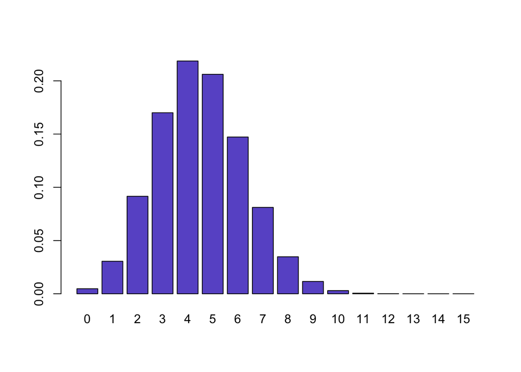

```r
barplot(probs, names.arg = 0:15, col = "slateblue")
```

Thus, X distributed as a binomial distribution with parameters (n = trial count, p = probability) is X ~ B(n,p).

Further, the probability of seeing X = k successes is:

P(X=k) = (n k) p^k x (1-p)^(n-k)

What is the output for k=3, p=.667, n=4?

```r
choose(4,3) * .667^3 * (1-.667)^(4-3)
```

```
## [1] 0.395259
```

or…

```r
dbinom(3, 4, .667)
```

```
## [1] 0.395259
```

### 1.3.3 Poisson distributions for modern fishies

The Poisson distribution can overtake the binomial distribution if p is small and n is large. The rate parameter of a Poisson distribution is:

lambda = np

For a Poisson distribution:

P(X=k) = (lambda^k x e^-lambda) / k!

To find P(X=3):

```r
(5^3 * exp(-5))/factorial(3)
```

```
## [1] 0.1403739
```

Note: this is the same answer as:

dpois(x=3, lambda=5)

Let’s simulate mutations along an HIV genome.

```r
rbinom(1, prob=5e-4, size=10000)
```

```
## [1] 3
```

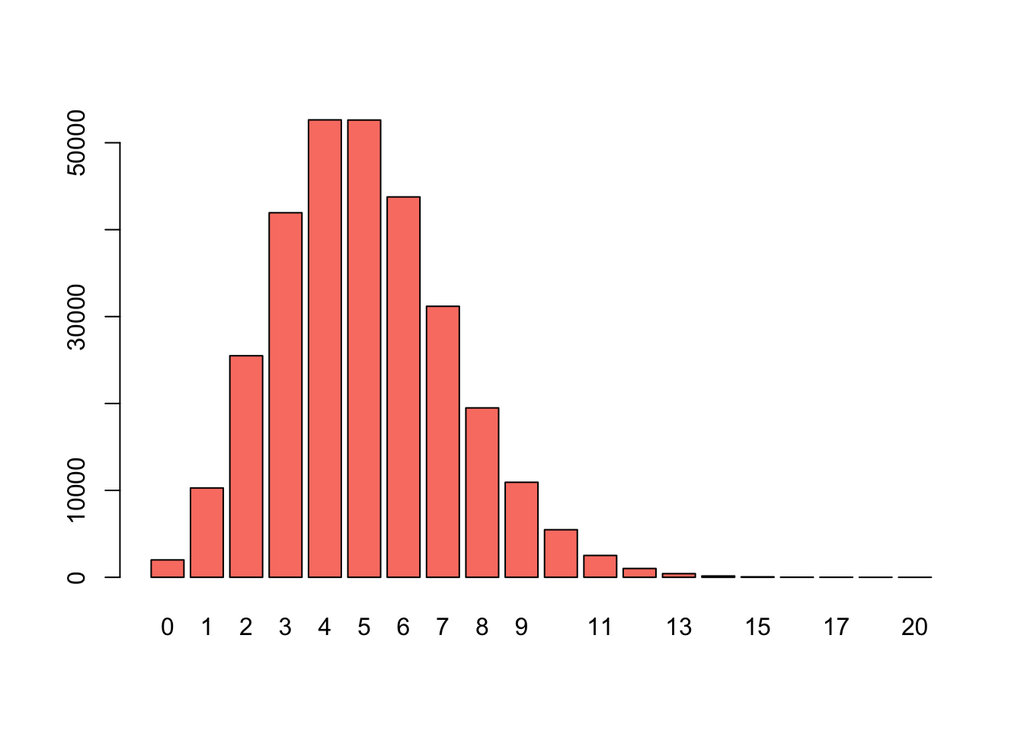

```r
simu = rbinom(n=300000, prob=5e-4,size=10000)
barplot(table(simu), col="salmon")
```

### 1.3.4 Applying these principles to epitope detection.

For conducting an ELISA assay there are known errors involved with:

- baseline noise level/false positive rate of 0.01, this can be defined as P(declare epitope | no epitope)
- the protein is tested at 100 independent and different positions
- a data collection from a patient is 50 samples

So p = 0.01, n = 50, and lambda = 0.5.

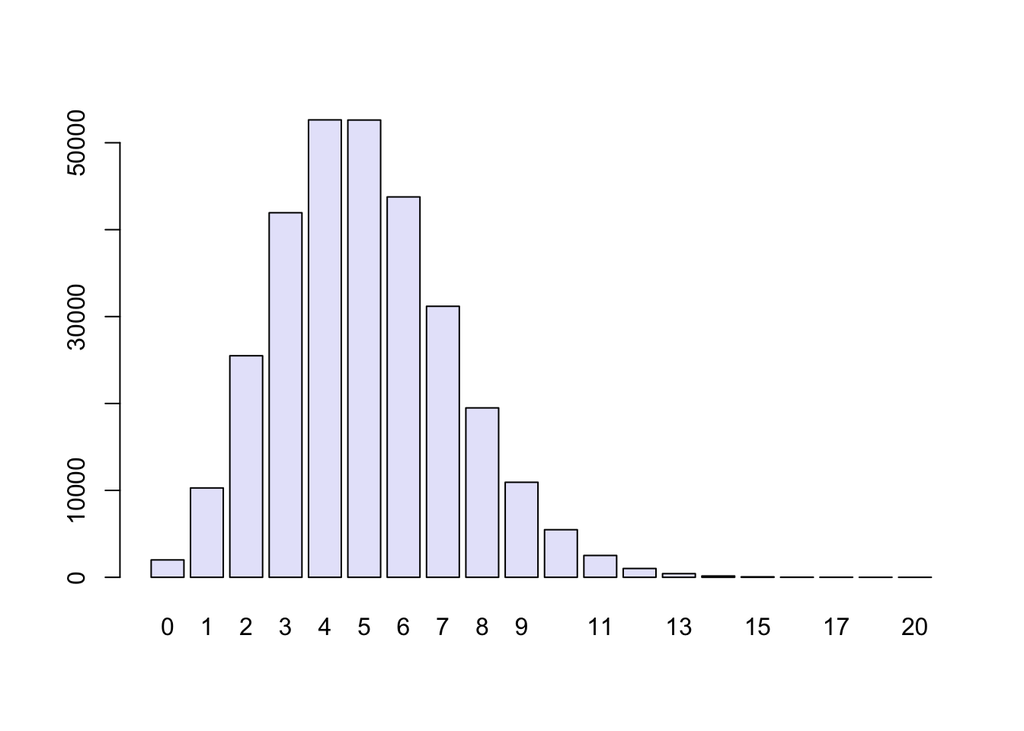

```r
simu1 = rbinom(n=50, prob=0.01,size=100)
barplot(table(simu), col="lavender")
```

```r
dpois(100, 0.01)
```

```
## [1] 0
```

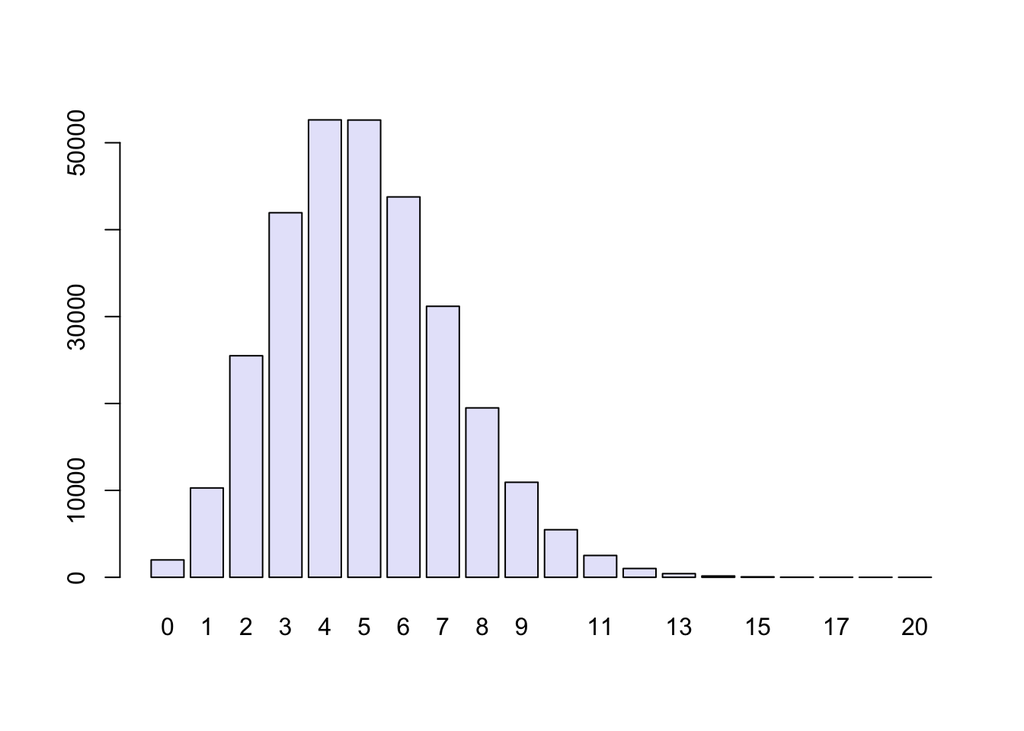

```r
simu2 = rpois(n=50, lambda=0.05)
barplot(table(simu), col="lavender")
```

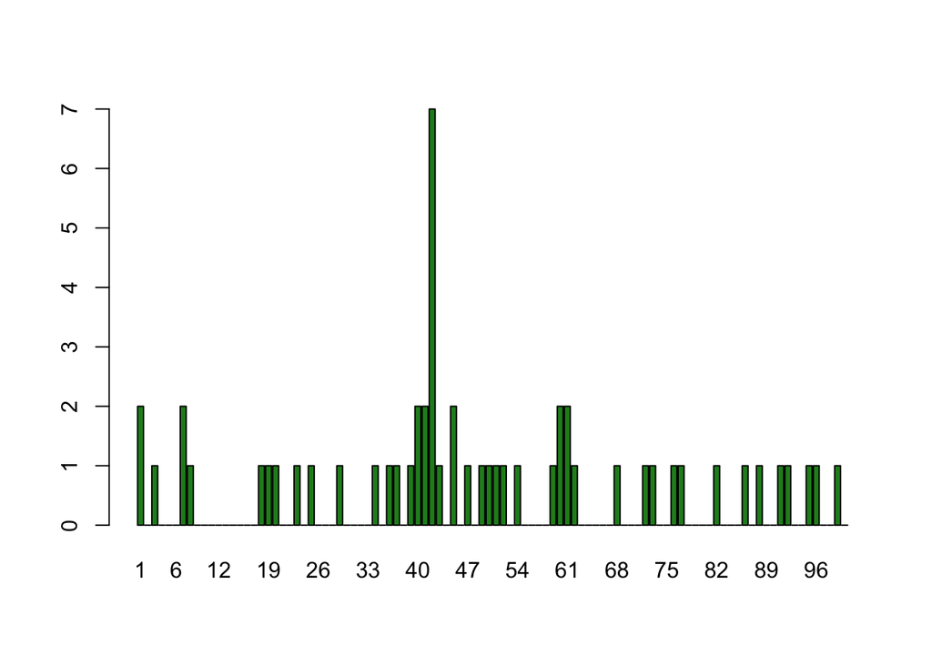

```r
load("/Users/jeremiahyarmie/Desktop/stat7160/data/e100.RData")
barplot(e100, names.arg = seq(along = e100), col ="forestgreen")
```

What’s surprising and expected here is a spike of 7 mutations. This leads us to ask:

- What is the probability of seeing a value as large as 7 if thereare no epitopes present (null hypothesis).

This is the same as 1- the probability of seeing a spike of 6 or less, known as the *cumulative distribution*, which can be found with ppois()

```r
1 - ppois(6, 0.5)
```

```
## [1] 1.00238e-06
```

This can also be run with ppois() with the lower.tail argument being false (if TRUE (default), probabilities are P[X ≤ x], otherwise, P[X > x].)

```r
epsil <-ppois(6, 0.5, lower.tail = F)
epsil
```

```
## [1] 1.00238e-06
```

This probability is known as epsilon.

*BUT* this is not quite the right approach. What we should **really** be asking is what are the chances that the **maximum** of the Poisson distribution is as large as 7, given there are no epitopes present. This is an *extreme value* analysis using *rank statistics*.

The probability of 7 or higher being the maximum is the same as one minus the *complementary events* happening, having all events being six or less. These 100 events are independent, and so their probabilities can by multiplied.

We can use a Monte Carlo method to compute our probabilities using a simulation method. Looking at 100000 instances of picking the maximum, we get the following:

```r
maxes = replicate(100000, {
  max(rpois(100, 0.5))
})
table(maxes)
```

```
## maxes
##     1     2     3     4     5     6     7
##    11 23576 60475 14257  1564   110     7
```

```r
mean(maxes >= 7)
```

```
## [1] 7e-05
```

This is about 10^-4.

But we are lucky in our approach. We known information that might not always be present in our analyses. We know the false positive rate, but that’s not always a given. Because of this, this approach is a **top-down, deductive**, *probability or generative modeling approach*.

A **bottom-up approach** centreing *statistical modeling* is covered in chapter 2.

## 1.4 Multinomial distributions

We must consider *multinomial distributions* when there are **more than two levels**, for example with a DNA sequence: A, T, G, C.

These different levels will have their own corresponding probability values pA, pG, pT, and pC. And their sum (should) equal to 1.

For example, for a DNA sequence where all four nucleotides are likely, what is the probability of seeing a hexemer sequence of 4 As and two Ts and no Gs or Cs?

```r
dmultinom(c(4, 2, 0, 0), prob = rep(1/4, 4))
```

```
## [1] 0.003662109
```

### 1.4.1 Simulating for power

An approach for using Monte Carlo for the multinomial: how big of a sample size do I need?

The term *power* refers to the probability of detecting something if it **is** there, or the *true positive rate*.

Power thresholds of 80% are common, meaning that if the experiment is run many times, about 20% of them will be false negatives (negative result when condition is present).

If he had an octamer of DNA with equal nucleotide probabilities, we will not always see the presence of all nucleotides in proportion.

```r
pvec = rep(1/4, 4)
t(rmultinom(1, prob = pvec, size = 8))
```

```
##      [,1] [,2] [,3] [,4]
## [1,]    3    1    2    2
```

So let’s increase the length of our DNA oligo to 20 and run 1000 simulations.

```r
obsunder0 = rmultinom(1000, prob = pvec, size = 20)
dim(obsunder0)
```

```
## [1]    4 1000
```

```r
obsunder0[, 1:11]
```

```
##      [,1] [,2] [,3] [,4] [,5] [,6] [,7] [,8] [,9] [,10] [,11]
## [1,]    6    4    5    5    5    4    6    9    6     4     6
## [2,]    4   11    6    8    5    8    4    3    2     5     4
## [3,]    3    1    4    2    5    3    5    3    4     1     5
## [4,]    7    4    5    5    5    5    5    5    8    10     5
```

How does the generated data differ from what we expected?

```r
stat = function(obsvd, exptd = 20 * pvec) {
  sum((obsvd - exptd)^2 / exptd)
}
stat(obsunder0[, 1])
```

```
## [1] 2
```

So for all of the measurements, we can store this data in a vector S0:

```r
S0 = apply(obsunder0, 2, stat)
summary(S0)
```

```
##    Min. 1st Qu.  Median    Mean 3rd Qu.    Max.
##    0.00    1.20    2.80    3.09    4.00   18.00
```

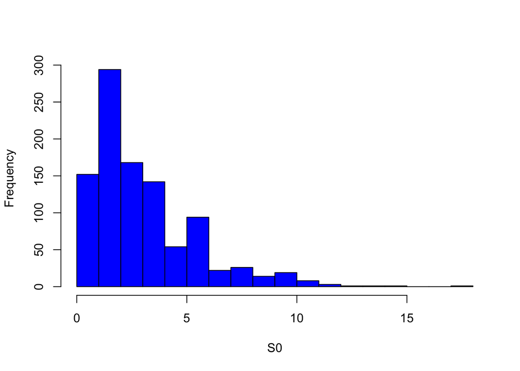

```r
hist(S0, breaks = 25, col = "blue", main = "")
```

and the 95% quantile:

```r
q95 = quantile(S0, probs = 0.95)
q95
```

```
## 95%
##   8
```

Now we generate 1000 simulations from an alternative (non-fair nucleotide) process for comparison.

```r
pvecA = c(3/8, 1/4, 3/12, 1/8)
observed = rmultinom(1000, prob = pvecA, size = 20)
dim(observed)
```

```
## [1]    4 1000
```

```r
apply(observed, 1, mean)
```

```
## [1] 7.554 5.028 4.982 2.436
```

```r
expectedA = pvecA *20
expectedA
```

```
## [1] 7.5 5.0 5.0 2.5
```

Our question is how often out of our 1000 instances will our test detect that the data departs from the null?

```r
stat(observed[,1])
```

```
## [1] 6
```

```r
S1 = apply(observed, 2, stat)
q95
```

```
## 95%
##   8
```

```r
sum(S1 > q95)
```

```
## [1] 199
```

```r
power = mean(S1>q95)
power
```

```
## [1] 0.199
```

What this all means is that:

- over 1000 simulations, 199 were identified as coming from an alternative distribution
- the probability P(reject Ho | Ha) is 0.199
- with a sequence length of n=20, we have a power of about 20% to detect the different between the fair generating process and our alternative

…

# 1.7 Further Exercises!

### 1.1

Other discrete variables include geometric and hypergeometric.

### 1.2

We can sum various dbinom() calls…

```r
dbinom(0, 10, 0.3) + dbinom(1, 10, 0.3) + dbinom(2, 10, 0.3)
```

```
## [1] 0.3827828
```

but this could look nicer…

```r
sum(dbinom(0:2, 10, 0.3))
```

```
## [1] 0.3827828
```

or we could use pbinom()

```r
pbinom(2, 10, 0.3)
```

```
## [1] 0.3827828
```

### 1.3

```r
pois_max <- function(n, max, lambda){
  1 - ppois(max-1, lambda)^n
  }
```

### 1.4

```r
pois_max_corr <- function(n=10, max=8, lambda=5){
  1 - ppois(max-1, lambda)^n
  }
```

### 1.5

```r
pois_max(n=100, max=9, lambda=5)
```

```
## [1] 0.9991346
```

### 1.6

Standard normal, Beta, Uniform, Exponential,

### 1.7

```r
randompois <- rpois(100, 3)
randompois %>% mean()
```

```
## [1] 3.08
```

```r
randompois %>% var()
```

```
## [1] 2.963232
```

### 1.8

C. elegans genome nucleotide frequency: Is the mitochondrial sequence of C. elegans consistent with a model of equally likely nucleotides?

1. Explore the nucleotide frequencies of chromosome M by using a dedicated function in the Biostrings package from Bioconductor.

```r
mito_length <- length(BSgenome.Celegans.UCSC.ce2$chrM)
div_by_mito <- function(x){x / mito_length}
nt_count <- BSgenome.Celegans.UCSC.ce2$chrM %>% letterFrequency(c("A","C","G","T"))
nt_freq <- sapply(nt_count, div_by_mito)
nt_freq
```

```
##          A          C          G          T
## 0.31426707 0.08880673 0.14897782 0.44794838
```

…